# Projeto de Aprendizado de Máquina: Predizendo o Sexo de Pinguins

# INTRODUÇÃO

O aprendizado de máquina é a ciência da programação de computadores de modo que eles possam aprender com os dados (Géron 2019). Isso significa que, dado um conjunto de dados e feito as devidas técnicas de pré-processamento, um algortitmo pode identificar padrões sejam eles sutís ou não, para então inferir novos valores desse conjunto de dados.

Por ser uma área multidisciplinar, o aprendizado de máquina possui diversas aplicações. No campo das finanças, podem ser adaptados para previsão com séries temporais, na medicina, podem identificar doenças tais como o câncer de pele, na agricultura, conseguem definir se uma safra de trigo está danificada ou não. Os algoritmos preditivos são bem generalistas e facilmente adaptáveis em vários outros setores.

No presente relatório, são usadas técnicas de coleta, divisão, análise, pré-processamento e transformação de dados nos conjuntos de dados de pinguins na Antártica(Horst, Hill, and Gorman 2020) com o objetivo de classificar se um pinguim se trata de uma fêmea ou um macho. Para tanto, foi utilizado o *software* R(R Core Team 2021) juntamente com bibliotecas aprópriadas para o aprendizado de máquina.

# REFERÊNCIAL TEÓRICO

## Aprendizado de Máquina

O aprendizado de máquina é o subcampo da inteligência artificial que tem como objetivo dá as máquinas a capacidade de aprender com os dados sem serem explicitamente programadas para isso (Abu-Mostafa, Magdon-Ismail, and Lin 2012). Isso significa que o algoritmo preditivo consegue compreender os processos subjacentes que estão nos dados e assim conseguir inferir novas informações. Com o advento da internet e juntamente com o aumento na aquisição de dados, o aprendizado de máquina ganhou um notório espaço interdisciplinar sendo bastante utilizada em vários outros setores como na saúde finanças, biologia, matemática e etc.

### Supervisionado

No aprendizado supervisionado, o conjunto de dados utilizado para a a utilização de algoritmos preditivos possui rótulos explícitos em sua composição. Isso significa que dado um conjunto de dados, para realizar uma tarefa do tipo supervisionado, é necessário que haja rótulos, sejam eles cateǵoricos como é o caso da classificação ou números reais como a regressão, como por exemplo a predição de valores de casas ou a predição de doenças.

### Não Supervisionado

Ao contrário do aprendizado supervisionado, no não supervisionado o conjunto de dados não possui rótulo, isso significa que o algoritmo não só vai identificar os padrões nos dados, como também será responsável em dizer a que classe pertence. Um exemplo de aplicação seria a segmentação de clientes, onde é utilizado o algoritmo de clusterização para descobrir os tipos de clientes de uma determinada empresa.

## Técnicas de Divisão dos Dados

### *HOLDOUT*

Para a realização do processo de aprendizado de máquina, divide-se o conjunto de dados em duas partes: treino e teste. O *Holdout* divide em relação a uma porcentagem que geralmente possui valores como 70% treino e 30% teste. É uma das técnicas mais utilizadas e mais simples, o que ocasiona em pouco custo computacional.

### Validação Cruzada

Essa técnica de divisão de dados consiste em dividi-los em k *folds*(pacotes) e em cada iteração um *fold* deverá ser o teste e o resto será o treino. Ela leva vantagem na técnica de *Holdout* por fazer com que todos os dados sejam treinados e testados, porém ela é mais custosa computacionalmente falando.

## Técnicas de Validação

### Matriz de Confusão

A matriz de confusão é uma métrica que mostra as classificações feitas pelo algoritmo preditivo em comparação com a classe real(Géron 2019). Em uma classificação binária, ela possui os seguintes valores:

- **Verdadeiro Positivo:** Quando o modelo prediz uma classe como positiva e ela de fato é;
- **Verdadeiro Negativo:** Quando o modelo prediz uma classe como negativa e ela de fato é;
- **Falso Positivo:** Quando o modelo prediz uma classe como positiva e ela é negativa;
- **Falso Negativo** Quando o modelo prediz uma classe como negativa e ela é positiva;

Observe abaixo a sua forma binária:

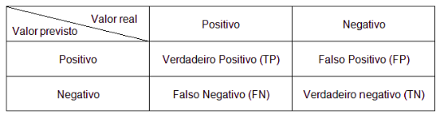

Fonte: https://ajuda.datarisk.io/knowledge

### *Precision*

O *Precision*, também chamada de acurácia das predições positivas, é a razão entre os verdadeiros positivos com a soma dos verdadeiros positivos e os falsos positivos(Géron 2019).

$$Precision = \frac{VP}{VP + FP}$$
Ela é bastante sensível aos falsos positivos, portanto muito utilizada para a avaliação do algoritmo preditivo e utilizada apenas nas tarefas de classificação.

### *Recall*

Ela é sensível aos falsos negativos, logo amplamente utilizada para a avaliar o algoritmo preditivo e utilizada apenas nas tarefas de classificação.

# METODOLOGIA

Um projeto de aprendizado de máquina pode ser feito seguindo os seguintes passos(Géron 2019):

- **Analisar o panorama geral:** Onde observamos do que se trata o problema e formulamos meios para resolve-lo;
- **Obter os dados:** Trata-se da coleta dos dados propriamente dita;
- **Divisão dos dados:** Onde acontece a divisão dos dados em dados de treino e teste, sendo o treino usado para treinamento e validação dos algoritmos preditivos e o teste usado apenas para estimar o erro fora da amostra;
- **Identificar e visualizar os dados:** Etapa de realizar a análise exploratória dos dados utilizando-se de ténicas estatísticas, tais como análises descritivas, gráficos, etc;
- **Pré-processamento e transformação dos dados:** Etapa onde tratamos os dados para servir de alimento para os algoritmos preditivos. Geralmente são imputados os valores ausentes e os dados númericos são transformados;
- **Selecionar e treinar modelos:** Etapa onde comparamos modelos com métricas em específico para então selecionar o melhor;
- **Aperfeiçoar o modelo:** Etapa onde aprimoramos o modelo escolhido escolhendo os melhores hiperpâmetros;
- **Teste:** Etapa final onde testamos o modelo aprimorado para estimar o erro fora da amostra.
- **Produção:** Depois de implementado, o modelo pode ser colocado na nuvem juntamente com uma aplicação que servirá para fornecer uma interface para utilizá-lo.

Para realizar todo o processo descrito acima, foi utilizado o *software* R com os seguintes pacotes:

Tabela 1: Descrição dos pacotes

| pacotes | descricao_pacotes |
| --- | --- |
| skimr | Pacote para resumos descritivos |
| tidyverse | Conjunto de pacotes para a manipulação dos dados |
| tidymodels | Pacotes para as etapas de aprendizado de máquina |
| palmerpenguins | Pacote para coletar os dados |
| reactable | Pacote para criação de tabelas dinâmicas |
| highcharter | Pacote para criação de gráficos |

# RESULTADOS E DISCUSSÕES

## Coleta de Dados

Primeiramente devemos pegar os dados da biblioteca *palmerpenguins*.

```r
data(package = 'palmerpenguins')
df = penguins
```

## Divisão dos dados

Após pegar o conjunto de dados, vamos dividi-lo em treino e teste. Essa divisão é feita antes de tudo com o objetivo de evitar o víes de espionagem. O viés de espionagem é usar o conjunto de dados de teste para identificar padrões nos dados. O conjunto de teste serve apenas para estimar o erro fora da amostra, identificar padrões nele acabaria por introduzir viés em seu modelo, tornando-o ineficiente. Uma analogia simples para compreender seria se um estudante tivesse acesso a prova de uma disciplina. Ele estudaria se baseando na prova e não no assunto, o que acarretaria em uma nota boa, mas ele não aprenderia a materia, já que um bom aluno estudaria pra adquirir conhecimento que por consequência gera uma boa nota na sua prova.

O tipo de divisão levou em consideração a proporção das classes da coluna alvo. Esse processo é chamado de amostragem por estratificação.

```r
set.seed(42)
divisao_dados = initial_split(df, strata = sex)
df_treino = training(divisao_dados)
df_teste = testing(divisao_dados)
```

## Análise exploratória

Agora é a parte de realizar análises nos dados.

### Estudo das Colunas

Abaixo segue o significado de cada coluna:

- *species:* Espécie do pinguim;
- *island:* Ilha onde foi registrado o pinguim;
- *bill length(mm):* Comprimento do bico em milímetros;
- *bill depth(mm):* Profundidade do bico em milímetros;
- *flipper length(mm):* Comprimento da nadadeira;
- *body mass (g):* Massa corporal em gramas;
- *sex:* Sexo do pinguim;
- *year:* Ano de registro do pinguim;

Foi feito uma tabela reativa dos dados.

```r
reactable(
  df_treino,
  defaultColDef = colDef(
  align = "center",
  header = function(valor) gsub('_',' ', valor, fixed = T),
  cell = function(valor) format(valor, nsmall = 1),
  minWidth = 40,
  headerStyle = list(background = "#f7f7f8")
  ),
  bordered = TRUE,
  highlight = TRUE,
  filterable = TRUE,
  searchable = TRUE
)
```

| species | island | bill_length_mm | bill_depth_mm | flipper_length_mm | body_mass_g | sex | year |
| --- | --- | --- | --- | --- | --- | --- | --- |
| Adelie | Torgersen | 39.5 | 17.4 | 186 | 3800 | female | 2007 |
| Adelie | Torgersen | 40.3 | 18 | 195 | 3250 | female | 2007 |
| Adelie | Torgersen | NA | NA | NA | NA | NA | 2007 |
| Adelie | Torgersen | 36.7 | 19.3 | 193 | 3450 | female | 2007 |
| Adelie | Torgersen | 38.9 | 17.8 | 181 | 3625 | female | 2007 |
| Adelie | Torgersen | 34.1 | 18.1 | 193 | 3475 | NA | 2007 |
| Adelie | Torgersen | 41.1 | 17.6 | 182 | 3200 | female | 2007 |
| Adelie | Biscoe | 37.8 | 18.3 | 174 | 3400 | female | 2007 |
| Adelie | Biscoe | 35.9 | 19.2 | 189 | 3800 | female | 2007 |
| Adelie | Biscoe | 40.5 | 17.9 | 187 | 3200 | female | 2007 |

[output cut: 247 more lines]

Com a biblioteca *skimr* podemos fazer um resumo descritivo dos dados. Abaixo observamos os resumos.

Aparentemente os dados não possui muita anormalidade, apenas alguns valores nulos.

```r
skim(df_treino) %>% yank('numeric')
```

**Variable type: numeric**

| skim_variable | n_missing | complete_rate | mean | sd | p0 | p25 | p50 | p75 | p100 | hist |
| --- | --- | --- | --- | --- | --- | --- | --- | --- | --- | --- |
| bill_length_mm | 1 | 1 | 43.87 | 5.35 | 32.1 | 39.45 | 43.7 | 48.12 | 59.6 | ▃▇▇▅▁ |
| bill_depth_mm | 1 | 1 | 17.17 | 2.03 | 13.1 | 15.47 | 17.3 | 18.72 | 21.5 | ▅▅▇▇▂ |
| flipper_length_mm | 1 | 1 | 200.23 | 13.38 | 172.0 | 190.00 | 197.0 | 212.00 | 231.0 | ▂▇▅▆▂ |
| body_mass_g | 1 | 1 | 4171.48 | 778.99 | 2700.0 | 3550.00 | 4050.0 | 4725.00 | 6300.0 | ▃▇▆▃▁ |
| year | 0 | 1 | 2007.98 | 0.81 | 2007.0 | 2007.00 | 2008.0 | 2009.00 | 2009.0 | ▇▁▇▁▇ |

O mesmo vale para os atributos categóricos.

```r
skim(df_treino) %>% yank('factor')
```

**Variable type: factor**

| skim_variable | n_missing | complete_rate | ordered | n_unique | top_counts |
| --- | --- | --- | --- | --- | --- |
| species | 0 | 1.00 | FALSE | 3 | Ade: 114, Gen: 89, Chi: 54 |
| island | 0 | 1.00 | FALSE | 3 | Bis: 127, Dre: 93, Tor: 37 |
| sex | 5 | 0.98 | FALSE | 2 | fem: 126, mal: 126 |

Observe que temos mais pinguins da espécie *Adalie*.

```r
df_treino  %>% count(species) %>% arrange(desc(n)) %>% hchart('column', hcaes(x =species, y = n)) %>% hc_colors(colors = 'lightblue')
```

[interactive chart not shown]

Aqui vemos mais pinguins na ilha de *Biscoe*.

```r
df_treino %>% count(island) %>% arrange(desc(n)) %>% hchart('column', hcaes(x = island, y = n)) %>% hc_colors(colors = 'lightblue')
```

[interactive chart not shown]

Observe que a variável alvo possui colunas com valores de contagem equilibrados, o que é uma ótima notícia. Valores de contagem equilibrados não geram viés.

```r
df_treino %>% filter(!is.na(sex)) %>% count(sex) %>% arrange(desc(n)) %>% hchart('column', hcaes(x = sex, y = n)) %>% hc_colors(colors = 'lightgreen')
```

[interactive chart not shown]

Observe que a espécie *Adalie* está presente em todas as ilhas, diferente das outras.

```r
df_treino %>% count(island,species) %>% hchart('bar', hcaes(x = island, y = n, group = species),
                                               color = c('lightgreen', "lightblue","lightpink") )
```

[interactive chart not shown]

Os histogramas abaixo tendem a ter uma certa simetria, por mais deformados que sejam.

```r
hchart(df_treino$bill_length_mm)
```

[interactive chart not shown]

```r
hchart(df_treino$bill_depth_mm)
```

[interactive chart not shown]

```r
hchart(df_treino$flipper_length_mm)
```

[interactive chart not shown]

```r
hchart(df_treino$body_mass_g)
```

[interactive chart not shown]

Observe que cada espécie possui um grupo característico que pode ser fácilmente dividido no gráfico. O que mostra que o comprimento da nadadeira e do bico faz com que cada espécie se destoe.

```r
hchart(df_treino, "scatter", hcaes(x = flipper_length_mm, y = bill_length_mm, group = species), color = c('yellow','green','blue'))
```

[interactive chart not shown]

O mesmo vale com a profundidade do bico e com seu comprimento.

```r
hchart(df_treino, 'scatter', hcaes(x = bill_depth_mm, y = bill_length_mm, group = species), color = c('yellow','green','blue'))
```

[interactive chart not shown]

Aparentemente o sexo não influencia tanto no comprimento da nadadeira e do bico.

```r
hchart(df_treino %>% filter(!is.na(sex)),'scatter', hcaes(x = flipper_length_mm, y =bill_length_mm, group = sex), color = c('yellow','blue'))
```

[interactive chart not shown]

Aparentemente algumas as fêmeas possuem uma massa corporal menor que a dos machos em relação ao comprimento do bico

```r
hchart(df_treino %>% filter(!is.na(sex)),'scatter', hcaes(x = body_mass_g, y =bill_length_mm, group = sex), color = c('yellow','blue'))
```

[interactive chart not shown]

## Imputação e transformação dos dados

Foi utilizado o pacote *recipes* do *tidymodels* para a imputação e transformação dos dados. Ele possui os seguintes passos:

- identificar a variável de saída e as preditoras;
- Imputar os dados;
- Transformar os dados.

O processo precisa ser na ordem, pois pode acarretar em erros.

```r
receita = recipe( sex ~., df_treino) %>%
  step_impute_median(all_numeric()) %>%
  step_impute_mode(all_nominal()) %>%
  step_dummy(all_nominal(),-all_outcomes()) %>%
  step_normalize(all_predictors())

receita
```

```
## Recipe
##
## Inputs:
##
##       role #variables
##    outcome          1
##  predictor          7
##
## Operations:
##
## Median imputation for all_numeric()
## Mode imputation for all_nominal()
## Dummy variables from all_nominal(), -all_outcomes()
## Centering and scaling for all_predictors()
```

preparando os dados.

```r
receita_final = bake(prep(receita), new_data = df_teste)
receita_final
```

```
## # A tibble: 87 × 10
##    bill_length_mm bill_depth_mm flipper_length_mm body_mass_g  year sex
##             <dbl>         <dbl>             <dbl>       <dbl> <dbl> <fct>
##  1         -0.350        1.49              -0.766       0.102 -1.20 female
##  2         -1.14        -0.0353            -1.07       -1.12  -1.20 female
##  3         -1.14         0.0634            -1.51       -0.606 -1.20 female
##  4         -1.36         0.310             -1.14       -0.606 -1.20 female
##  5         -0.968        0.902             -0.391      -0.927 -1.20 female
##  6         -1.77         0.606             -1.22       -1.09  -1.20 female
##  7         -1.60         0.853             -0.990      -0.477 -1.20 female
##  8         -0.818        0.310             -0.915      -1.12  -1.20 female
##  9         -1.38         0.409             -1.36       -1.31  -1.20 female
## 10         -0.575        0.606             -0.391      -0.349 -1.20 male
## # … with 77 more rows, and 4 more variables: species_Chinstrap <dbl>,
## #   species_Gentoo <dbl>, island_Dream <dbl>, island_Torgersen <dbl>
```

## Construção e Comparação de Modelos

Construido o processo de imputação e transformação, agora é hora de comparar modelos.

Para a comparação entre modelos, foi escolhido a validação cruzada.

```r
set.seed(42)
validacao_cruzada = vfold_cv(df_treino, v = 4)
```

Implementação do primeiro modelo: O *random forest*.

Para implementar um modelo no *tidymodels*, primeiro deve escolher o nome do modelo, colocar o modo dele(se é classificação ou regressão) e por fim sua *engine*, que seria o motor que vai processar os dados.

```r
random_forest = rand_forest() %>%
           set_mode('classification') %>% set_engine('ranger')

random_forest
```

```
## Random Forest Model Specification (classification)
##
## Computational engine: ranger
```

Foi utilizado a regressão logistica.

```r
logistic = logistic_reg() %>% set_engine('glm')

logistic
```

```
## Logistic Regression Model Specification (classification)
##
## Computational engine: glm
```

o *workflow* tem como função criar um container para adicionar componentes e evitar redundância de código.

```r
wf = workflow() %>% add_recipe(receita)
wf
```

```
## ══ Workflow ════════════════════════════════════════════════════════════════════
## Preprocessor: Recipe
## Model: None
##
## ── Preprocessor ────────────────────────────────────────────────────────────────
## 4 Recipe Steps
##
## • step_impute_median()
## • step_impute_mode()
## • step_dummy()
## • step_normalize()
```

As métricas utilizadas para validação foram o *precision* e o *recall*.

```r
logistic_resultado = wf %>% add_model(logistic) %>%
                           fit_resamples(resamples = validacao_cruzada,
                                         control = control_resamples(save_pred = TRUE, verbose = FALSE),
                            metrics = metric_set(precision,recall)
                           )

logistic_resultado
```

```
## # Resampling results
## # 4-fold cross-validation
## # A tibble: 4 × 5
##   splits           id    .metrics         .notes           .predictions
##   <list>           <chr> <list>           <list>           <list>
## 1 <split [192/65]> Fold1 <tibble [2 × 4]> <tibble [0 × 1]> <tibble [65 × 4]>
## 2 <split [193/64]> Fold2 <tibble [2 × 4]> <tibble [0 × 1]> <tibble [64 × 4]>
## 3 <split [193/64]> Fold3 <tibble [2 × 4]> <tibble [0 × 1]> <tibble [64 × 4]>
## 4 <split [193/64]> Fold4 <tibble [2 × 4]> <tibble [0 × 1]> <tibble [64 × 4]>
```

```r
rf_resultado = wf %>% add_model(random_forest) %>%
                      fit_resamples(resamples = validacao_cruzada,
                      control = control_resamples(save_pred = TRUE, verbose = FALSE),
                      metrics = metric_set(precision,recall)
                      )

rf_resultado
```

```
## # Resampling results
## # 4-fold cross-validation
## # A tibble: 4 × 5
##   splits           id    .metrics         .notes           .predictions
##   <list>           <chr> <list>           <list>           <list>
## 1 <split [192/65]> Fold1 <tibble [2 × 4]> <tibble [0 × 1]> <tibble [65 × 4]>
## 2 <split [193/64]> Fold2 <tibble [2 × 4]> <tibble [0 × 1]> <tibble [64 × 4]>
## 3 <split [193/64]> Fold3 <tibble [2 × 4]> <tibble [0 × 1]> <tibble [64 × 4]>
## 4 <split [193/64]> Fold4 <tibble [2 × 4]> <tibble [0 × 1]> <tibble [64 × 4]>
```

Aqui vemos que o desempenho da regressão logística se mostrou ser superior ao do *random forest*.

```r
collect_metrics(logistic_resultado)
```

```
## # A tibble: 2 × 6
##   .metric   .estimator  mean     n std_err .config
##   <chr>     <chr>      <dbl> <int>   <dbl> <chr>
## 1 precision binary     0.911     4  0.0382 Preprocessor1_Model1
## 2 recall    binary     0.895     4  0.0281 Preprocessor1_Model1
```

Aqui temos a matriz de confusão. Vemos que há poucos falsos positivos e negativos em cada modelo, mas a regressão se saiu vitoriosa, logo ela vai ser escolhida.

```r
logistic_resultado %>% conf_mat_resampled()
```

```
## # A tibble: 4 × 3
##   Prediction Truth   Freq
##   <fct>      <fct>  <dbl>
## 1 female     female  29
## 2 female     male     3
## 3 male       female   3.5
## 4 male       male    28.8
```

```r
collect_metrics(rf_resultado)
```

```
## # A tibble: 2 × 6
##   .metric   .estimator  mean     n std_err .config
##   <chr>     <chr>      <dbl> <int>   <dbl> <chr>
## 1 precision binary     0.891     4  0.0126 Preprocessor1_Model1
## 2 recall    binary     0.873     4  0.0344 Preprocessor1_Model1
```

```r
rf_resultado %>% conf_mat_resampled()
```

```
## # A tibble: 4 × 3
##   Prediction Truth   Freq
##   <fct>      <fct>  <dbl>
## 1 female     female 28.2
## 2 female     male    3.5
## 3 male       female  4.25
## 4 male       male   28.2
```

Antes de testar, é preferível realizar a etapa de aprimoramento do modelo, porém o motor da regressão logistica não permite aprimoramento, logo vamos pular essa parte. Não irá prejudicar o modelo, já que ele já é um bom modelo por si só.

## Teste Final

Treinando o modelo com os dados de treino e testando-o

```r
modelo_final = wf %>% add_model(logistic) %>% last_fit(divisao_dados, metrics = metric_set(precision,recall))
modelo_final
```

```
## # Resampling results
## # Manual resampling
## # A tibble: 1 × 6
##   splits           id               .metrics .notes   .predictions .workflow
##   <list>           <chr>            <list>   <list>   <list>       <list>
## 1 <split [257/87]> train/test split <tibble> <tibble> <tibble>     <workflow>
```

Observe que o desempenho continuou exelente, portanto o modelo está apto a realizar o processo de *deploy*, que seria jogá-lo na nuvem.

```r
collect_metrics(modelo_final)
```

```
## # A tibble: 2 × 4
##   .metric   .estimator .estimate .config
##   <chr>     <chr>          <dbl> <chr>
## 1 precision binary         0.953 Preprocessor1_Model1
## 2 recall    binary         0.911 Preprocessor1_Model1
```

# REFERÊNCIAS BIBLIOGRÁFICAS

Abu-Mostafa, Yaser S, Malik Magdon-Ismail, and Hsuan-Tien Lin. 2012. *Learning from Data*. Vol. 4. AMLBook New York.

Géron, Aurélien. 2019. *Hands-on Machine Learning with Scikit-Learn, Keras, and TensorFlow: Concepts, Tools, and Techniques to Build Intelligent Systems*. " O’Reilly Media, Inc.".

Horst, Allison Marie, Alison Presmanes Hill, and Kristen B Gorman. 2020. *Palmerpenguins: Palmer Archipelago (Antarctica) Penguin Data*. https://doi.org/10.5281/zenodo.3960218.

R Core Team. 2021. *R: A Language and Environment for Statistical Computing*. Vienna, Austria: R Foundation for Statistical Computing. https://www.R-project.org/.